# Sissejuhatus JAGS-i

Siim Põldre

4 11 2020

```r
library("rjags")
```

R-is JAGS-i mudeli jooksutamises on neli sammu:

1. Määra mudel
2. Pane mudel töövalmis
3. Jooksuta MCMC samplerit
4. Järeltöötlus

Järgnevalt vaatame neid samme juba eelnevalt käsitletud näite varal, kus uurime personali protsentuaalset muutust eelmise aastaga võrreldes n = 10 ettevõtte puhul. Me kasutasime normaaljaotuslikku *likelihood* funktsiooni, mille variatsioon on teada, ning t jaotusega priorit teadmata keskmise jaoks.

## 1. Määra mudel

Siin sammus anname me JAGSile mudeli hierargilise struktuuri, määrates andmetele jaotused (*likelihood*) ja parameetrid (*priors*).

Meie hierarhiline mudel näeab matemaatiliselt välja selline:

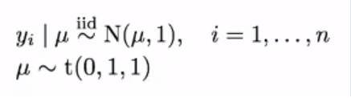

Normal likelihood with t prior

Esimese sammu süntaks on R-ile väga sarnane, kuid on palju võtmetähtsusega erinevusi.

- n - andmete suurus
- 1.0/sig2 - precision ega variatsiooni reciprocal

```r
mod_string = " model {
  for (i in 1:n) {
    y[i] ~ dnorm(mu, 1.0/sig2)
  }
  mu ~ dt(0.0, 1.0/1.0, 1.0) # location, inverse scale, degrees of freedom
  sig2 = 1.0
} "
```

Suurim vahe JAGSi ja Ri süntaksi vahel on see, kuidas jaotuseid parametriseeritakse. Pane tähele, et normaaljaotus kasutab keskmist ja täpsust *precision* (variatsiooni asemel). Pannes JAGS-is jaotuseid paika, on alati mõistlik vaadata JAGSi kasutusjuhendist peatükki jaotustest.

## 2. Pane mudel töövalmis

```r
set.seed(50)
y = c(1.2, 1.4, -0.5, 0.3, 0.9, 2.3, 1.0, 0.1, 1.3, 1.9)
n = length(y)

data_jags = list(y=y, n=n)
params = c("mu")

inits = function() {
  inits = list("mu"=0.0)
} # optional (and fixed)

mod = jags.model(textConnection(mod_string), data=data_jags, inits=inits)
```

Algsete väärtuste määramiseks on mitmeid viise. Nad saab ise paika panna, nagu me oleme siin teinud, või nad saab määrata juhuslikena, nt list(“mu”=rnorm(1)). Samuti võib algsed väärtused lihtsalt välja jätta ning JAGS paneb nad ise paika.

## 3. MCMC sampleri jooksutamine

```r
update(mod, 500) # burn-in

mod_sim = coda.samples(model=mod,
                       variable.names=params,
                       n.iter=1000)
```

coda.samples-sist räägime edaspidistes näidetes.

## 4. Järeltöötlus

```r
summary(mod_sim)
```

```
##
## Iterations = 1501:2500
## Thinning interval = 1
## Number of chains = 1
## Sample size per chain = 1000
##
## 1. Empirical mean and standard deviation for each variable,
##    plus standard error of the mean:
##
##           Mean             SD       Naive SE Time-series SE
##        0.88070        0.31307        0.00990        0.01327
##
## 2. Quantiles for each variable:
##
##   2.5%    25%    50%    75%  97.5%
## 0.2492 0.6668 0.8718 1.0925 1.4828
```

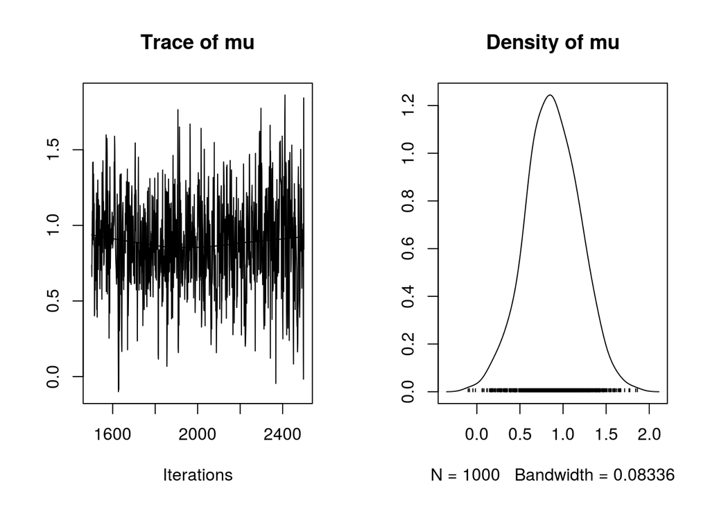

```r
library("coda")
plot(mod_sim)
```

Järgnevates loengutes käsitleme järeltöötlust sügavamalt.